# Clase 7 - Parámetros del cambio de precio

Sam

2025-02-11

Ya sabemos que los cambios en el precio tienen un comportamiento dado por la EDE:

$$dS=S_o \mu dt + S_o \sigma dW$$

Los valores de los parámetros $\mu$ y $\sigma$ dependen del tiempo, por lo cual debemos definir si serán diarios, serán analizados o que características vamos a considerar.

```r
library(quantmod)
library(lubridate)
clave <- 'GFNORTEO.MX'
datos <- new.env()
getSymbols(clave, from = '2000-01-02', to = today(), env=datos)
```

```
## [1] "GFNORTEO.MX"
```

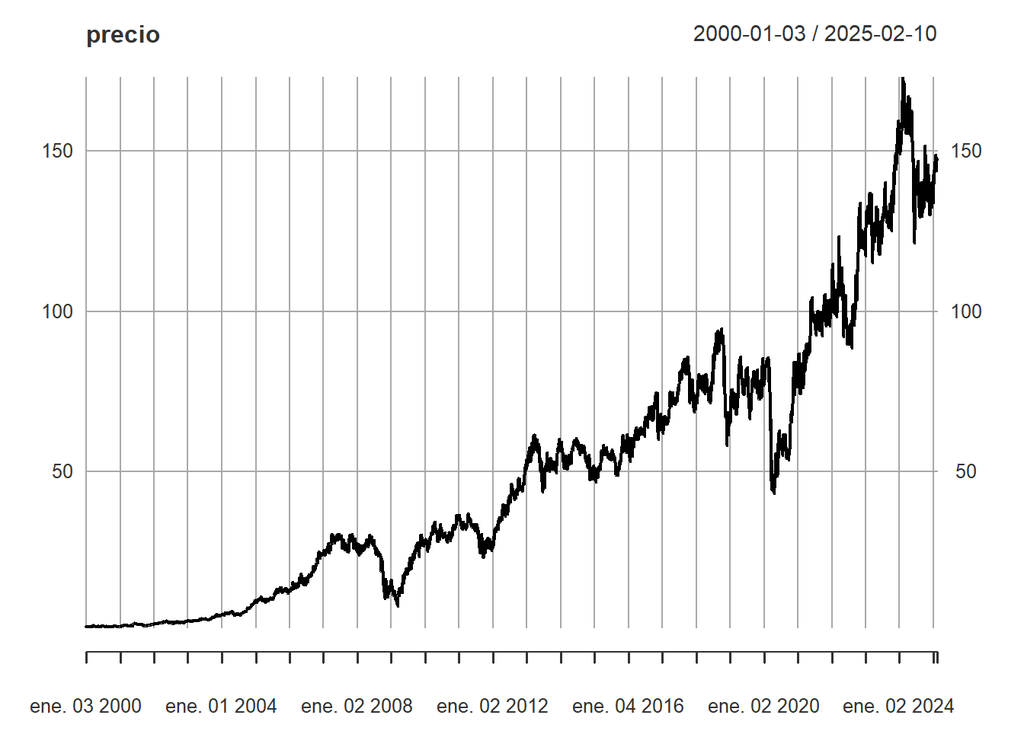

```r
precio <- datos[[clave]][,6]
plot(precio)
```

Nuestro análisis es sobre el rendimiento

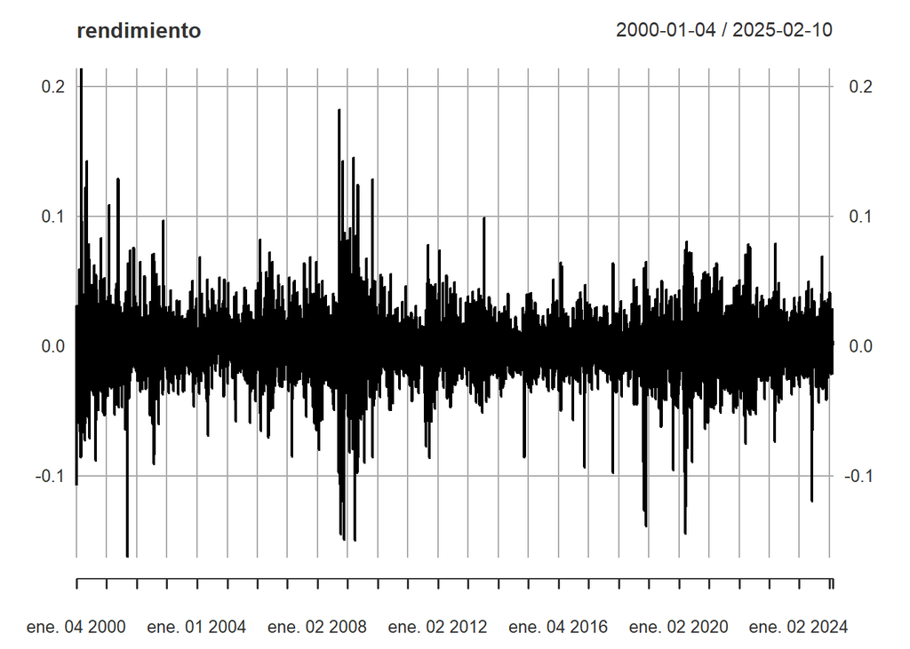

```r
rendimiento <- na.omit(diff(log(precio)))
plot(rendimiento)
```

Deciamos que los parámetros dependen del tiempo. Primero consideramos los datos históricos, es decir, todos los que existen.

```r
mu_di_hist <- mean(rendimiento)
sigma_di_hist <- sd(rendimiento)
mu_di_hist
```

```
## [1] 0.0006874502
```

```r
sigma_di_hist
```

```
## [1] 0.02301177
```

```r
# Estos resultados son comúnes en un activo
```

Estos parámetros podemos anualizarlos para que tengan una mejor interpretación.

```r
mu_anual_his <- mean(rendimiento)*252
sigma_anual_his <- sd(rendimiento)*sqrt(252)
mu_anual_his
```

```
## [1] 0.1732375
```

```r
sigma_anual_his
```

```
## [1] 0.3653006
```

Vamos a calcular estos mismos parámetros para cada uno de los años de información que tenemos.

```r
library(dplyr)
names(rendimiento) <- 'rend'
tabla <- rendimiento |>
  as_tibble() |>
  mutate(anio = year(rendimiento)) |>
  group_by(anio) |>
  summarise('Ren_Diario' = mean(rend),
            'Vol_Diario' = sd(rend),
            'Ren_Anual' = mean(rend) * 252,
            'Vol_Anual' = sd(rend) * sqrt(252))
tabla
```

```
## # A tibble: 26 × 5
##     anio Ren_Diario Vol_Diario Ren_Anual Vol_Anual
##    <dbl>      <dbl>      <dbl>     <dbl>     <dbl>
##  1  2000  -0.000325     0.0356   -0.0818     0.564
##  2  2001   0.00147      0.0264    0.371      0.419
##  3  2002   0.00128      0.0228    0.323      0.362
##  4  2003   0.00170      0.0159    0.430      0.253
##  5  2004   0.00231      0.0167    0.583      0.266
##  6  2005   0.000975     0.0160    0.246      0.254
##  7  2006   0.00250      0.0225    0.630      0.357
##  8  2007   0.000293     0.0215    0.0739     0.342
##  9  2008  -0.00228      0.0382   -0.574      0.606
## 10  2009   0.00261      0.0388    0.658      0.616
## # ℹ 16 more rows
```

Hasta ahora hemos considerado que los rendimientos tienen el supuesto de normalidad (Esto sucede porque los rendimientos se explican por un proceso estocástico determinado por un $\epsilon$ que tiene media 0 y varianza 1). Veamos el histograma del rendimiento:

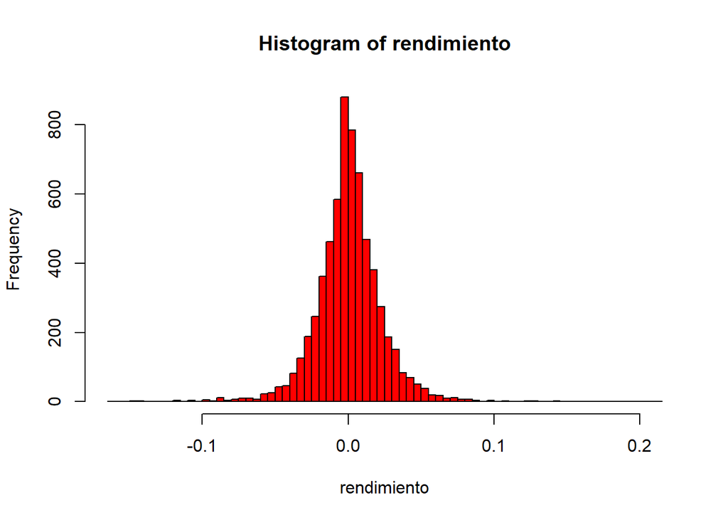

```r
hist(rendimiento, n=100, col='red')
```

Vamos a efectuar una prueba formal de NORMALIDAD. Una prueba formal nos indica, si estrictamente la variable sigue o no el comportamiento deseado. En este caso, la prueba que usaremos se llama Jarque-Bera y consiste en una prueba de hipótesis, con una nula y otra alternativa y usamos el valor del p-value para decidir.

$H_o$ : Hay normalidad en los datos

$H_i$ : No hay normalidad

```r
library(moments)
jarque.test(as.numeric(rendimiento))
```

```
##
##  Jarque-Bera Normality Test
##
## data:  as.numeric(rendimiento)
## JB = 11885, p-value < 2.2e-16
## alternative hypothesis: greater
```

p-value < 0.05, por lo tanto rechazamos $H_o$ . Concluimos que los datos del rendimiento no son normales.

Why? Porque tienen leptocurtosis, es decir un exceso de curtosis respecto a lo que es normal.

La prueba que acabamos de hacer compara la distribución de los datos que le damos con los de una normal, la normal tiene 2 características, sesgo 0 y curtosis 3.

```r
skewness(rendimiento)
```

```
##        rend
## -0.02173153
```

```r
kurtosis(rendimiento)
```

```
##     rend
## 9.690027
```

Un sesgo negativo indica que los datos están un poco cargados a la izquierda, ‘Cola izquierda más pesada’.

```r
jarque.test(as.numeric(precio))
```

```
##
##  Jarque-Bera Normality Test
##
## data:  as.numeric(precio)
## JB = 730.43, p-value < 2.2e-16
## alternative hypothesis: greater
```

Ahora hagamos la prueba de rendimiento diario promedio = 0.

$H_o$ : La media del rendimiento diario es cero

$H_i$ : La media del rendimiento diario $\neq$ 0

```r
t.test(as.numeric(rendimiento), mu = 0, alternative = 'two.sided')
```

```
##
##  One Sample t-test
##
## data:  as.numeric(rendimiento)
## t = 2.3849, df = 6372, p-value = 0.01711
## alternative hypothesis: true mean is not equal to 0
## 95 percent confidence interval:
##  0.0001223718 0.0012525286
## sample estimates:
##    mean of x
## 0.0006874502
```

Considerando un $\alpha=0.01$ , fallamos en rechazar $H_o$ y concluimos que la media del rendimiento diario es igual a 0